# PRÁCTICA 2: Limpieza y validación de los datos

Autores: Anna Llorens Roig, Carlos Villar Robles

Dataset: Adults

## 1. Introducción

Esta práctica se ha realizado bajo el contexto de la asignatura *Tipología y ciclo de vida de los datos*, perteneciente al Máster en Ciencia de Datos de la Universitat Oberta de Catalunya. En ella, se aplican técnicas de *limpieza y validación de de los datos* mediante el lenguaje de programación R para realizar un analális de datos del dataset *Adults* proporcionado por el repositorio de UCI Machine Learning.

### 1.1 Miembros del equipo

La actividad ha sido realizada por:

- Anna Llorens Roig (Aula1)
- Carlos Villar Robles (Aula2)

### 1.2 Contenido del repositorio

- **data/adults.csv**: Punto de entrada al programa. Datos originales.
- **data/adults_clean.csv**: Fichero de salida de datos.
- **code/adults.Rmd**: Código de resolución de la actividad en R.
- **code/adults.pdf**: Respuestas actividad en formato pdf.
- **code/adults.html**: Respuestas actividad en formato html.

### 1.3 Enlace a git

https://github.com/annallorens/datacleaning

## 2. Descripción del dataset

El conjunto de datos objeto de análisis es de la base de datos ‘data’ del Censo de 1994 en Estados Unidos. Los detalles de este conjunto de datos se pueden encontrar en el repositorio de UCI Machine Learning: https://archive.ics.uci.edu/ml/datasets/adult.

Se trata del ‘adults data set’ el cual consta de 15 atributos y 32561 observaciones. Entre los campos del conjunto de datos encontramos las siguientes variables dependientes:

- **age**: edad del individuo
- **type_employer**: tipo de empleador que tiene el individuo. Ya sean gubernamentales, militares, privados, etc.
- **fnlwgt**: El # de personas que los encuestados creen que representa la observación. Ignoraremos esta variable
- **education**: nivel más alto de educación alcanzado para esa persona
- **education_num**: nivel más alto de educación en forma numérica
- **marital**: estado civil del individuo
- **occupation**: ocupación del individuo
- **relationship**: contiene valores de relaciones familiares como marido, padre, etc., pero solo contiene uno por observación
- **race**: descripciones de la raza individual. Negro, blanco, esquimal,
- **sex**: sexo del individuo
- **capital_gain**: ganancias de capital registradas
- **capital_loss**: pérdidas de capital registradas
- **hr_per_week**: horas trabajadas por semana
- **country**: país de origen del individuo

Cómo variable dependiente del dataset tenemos:

- **income**: variable booleana. Representa si la persona gana o no más de $ 50,000 por año de ingresos.

### 2.1 Importación de librerías

Cargamos las librerías R que vamos a utilizar para la resolución de la práctica

```r
# Libreria de visualizacion de datos
library("ggplot2")

# Librerías para la generación de grids
library("grid")
library("gridExtra")

# Librería para obtención de información detallada
library("gmodels")
```

## 3. Inegración y selección de los datos de interés.

Antes de comenzar con la limpieza de los datos, procedemos a realizar la lectura del fichero en formato CSV en el que se encuentran. El resultado devuelto por la llamada a la función read.csv() será un objeto data.frame el cual mostraremos su cabecera:

```r
# Lectura de datos
data <-read.csv('../data/adults.csv', header = TRUE)
```

```r
# Comprobamos que los datos se han importado correctamente
head(data[,1:5])
```

```
##   age        workclass fnlwgt education education_num
## 1  39        State-gov  77516 Bachelors            13
## 2  50 Self-emp-not-inc  83311 Bachelors            13
## 3  38          Private 215646   HS-grad             9
## 4  53          Private 234721      11th             7
## 5  28          Private 338409 Bachelors            13
## 6  37          Private 284582   Masters            14
```

Un resumen de alto nivel de los datos se encuentra a continuación. Todas las variables han sido leídas en sus clases esperadas.

```r
str(data)
```

```
## 'data.frame':    32561 obs. of  15 variables:
##  $ age           : int  39 50 38 53 28 37 49 52 31 42 ...
##  $ workclass     : Factor w/ 9 levels "?","Federal-gov",..: 8 7 5 5 5 5 5 7 5 5 ...
##  $ fnlwgt        : int  77516 83311 215646 234721 338409 284582 160187 209642 45781 159449 ...
##  $ education     : Factor w/ 16 levels "10th","11th",..: 10 10 12 2 10 13 7 12 13 10 ...
##  $ education_num : int  13 13 9 7 13 14 5 9 14 13 ...
##  $ maritalStatus : Factor w/ 7 levels "Divorced","Married-AF-spouse",..: 5 3 1 3 3 3 4 3 5 3 ...
##  $ occupation    : Factor w/ 15 levels "?","Adm-clerical",..: 2 5 7 7 11 5 9 5 11 5 ...
##  $ relationship  : Factor w/ 6 levels "Husband","Not-in-family",..: 2 1 2 1 6 6 2 1 2 1 ...
##  $ race          : Factor w/ 5 levels "Amer-Indian-Eskimo",..: 5 5 5 3 3 5 3 5 5 5 ...
##  $ sex           : Factor w/ 2 levels "F","M": 2 2 2 2 1 1 1 2 1 2 ...
##  $ capital_gain  : int  2174 0 0 0 0 0 0 0 14084 5178 ...
##  $ capital_loss  : int  0 0 0 0 0 0 0 0 0 0 ...
##  $ hour_per_week : int  40 13 40 40 40 40 16 45 50 40 ...
##  $ native_country: Factor w/ 42 levels "?","Cambodia",..: 40 40 40 40 6 40 24 40 40 40 ...
##  $ income        : Factor w/ 2 levels "<=50K",">50K": 1 1 1 1 1 1 1 2 2 2 ...
```

```r
# Eliminamos variables
data$education <- NULL
data$fnlwgt <- NULL
data$relationship <- NULL
data$capital_gain <- NULL
data$capital_loss <- NULL
data$native_country <- NULL
data$race <- NULL
```

## 4. Limpieza de los datos.

Una vez tenemos el conjunto de datos con el que trabajaremos observamos el resumen del conjuto y pasaremos a la limpieza de estos.

```r
summary(data)
```

```
##       age                   workclass     education_num
##  Min.   :17.00   Private         :22696   Min.   : 1.00
##  1st Qu.:28.00   Self-emp-not-inc: 2541   1st Qu.: 9.00
##  Median :37.00   Local-gov       : 2093   Median :10.00
##  Mean   :38.58   ?               : 1836   Mean   :10.08
##  3rd Qu.:48.00   State-gov       : 1298   3rd Qu.:12.00
##  Max.   :90.00   Self-emp-inc    : 1116   Max.   :16.00
##                  (Other)         :  981
##                maritalStatus             occupation   sex
##  Divorced             : 4443   Prof-specialty :4140   F:10771
##  Married-AF-spouse    :   23   Craft-repair   :4099   M:21790
##  Married-civ-spouse   :14976   Exec-managerial:4066
##  Married-spouse-absent:  418   Adm-clerical   :3770
##  Never-married        :10683   Sales          :3650
##  Separated            : 1025   Other-service  :3295
##  Widowed              :  993   (Other)        :9541
##  hour_per_week     income
##  Min.   : 1.00   <=50K:24720
##  1st Qu.:40.00   >50K : 7841
##  Median :40.00
##  Mean   :40.44
##  3rd Qu.:45.00
##  Max.   :99.00
##
```

### 4.1 Ceros y elementos vacios

Tal y como se indica en la descripción del dataset se utiliza el carácter ‘?’ para denotar un valor desconocido. Así, se procede a conocer a continuación qué campos contienen elementos vacíos:

```r
# Números de valores desconocidos por campo
colSums(data=="?")
```

```
##           age     workclass education_num maritalStatus    occupation
##             0          1836             0             0          1843
##           sex hour_per_week        income
##             0             0             0
```

```r
data<-data[!(data$workclass=="?"),]
data<-data[!(data$occupation=="?"),]
```

```r
# Comprobamos valores nulos
colSums(data=="?")
```

```
##           age     workclass education_num maritalStatus    occupation
##             0             0             0             0             0
##           sex hour_per_week        income
##             0             0             0
```

### 4.2 Identificación y tratamiento de valores extremos

Los valores extremos o outliers son aquellos que parecen no ser congruentes sin los comparamos con el resto de los datos. Para identificarlos, podemos hacer uso de dos vías: (1) representar un diagrama de caja por cada variable y ver qué valores distan mucho del rango intercuartílico (la caja) o (2) utilizar la función boxplots.stats() de R, la cual se emplea a continuación. Así, se mostrarán sólo los valores atípicos para aquellas variables que los contienen:

```r
boxplot.stats(data$age)$out
```

```
##   [1] 79 76 90 77 76 81 78 90 88 90 77 90 77 78 80 90 81 81 76 80 90 76 79
##  [24] 76 81 76 90 76 90 80 90 90 79 78 79 84 90 77 80 77 90 81 83 84 79 76
##  [47] 85 82 79 77 90 76 90 84 78 78 76 80 90 90 77 76 84 76 90 76 90 76 77
##  [70] 81 90 77 78 77 81 78 82 81 77 76 80 90 80 84 82 78 79 76 90 84 90 83
##  [93] 78 80 77 78 76 79 80 79 80 90 90 90 90 81 76 83 90 90 81 80 80 90 79
## [116] 77 77 80 76 82 85 80 79 90 76 76 77 76 79 81 77 88 90 82 76 88 76 77
## [139] 83 76 77 79 77 86 90 77 82 83 81 76 79 76 84 78 76 76 76 78 84 79 78
## [162] 90 80 81 78 81 90 80 82 90 90 85
```

```r
boxplot.stats(data$education_num)$out
```

```
##   [1] 1 2 2 2 2 1 2 2 2 2 2 2 2 2 2 1 1 2 1 2 1 2 2 2 2 2 2 2 2 2 2 2 2 2 2
##  [36] 1 1 1 2 2 2 2 2 1 1 2 2 2 2 1 2 2 2 2 2 2 2 2 2 1 2 2 2 2 1 2 1 2 2 2
##  [71] 2 2 2 2 2 1 2 2 2 2 2 2 2 2 2 2 2 2 1 2 2 2 2 2 1 1 2 2 2 2 2 2 1 2 2
## [106] 2 2 2 2 2 2 2 2 1 2 2 2 1 1 2 2 1 1 2 2 1 2 2 1 2 1 2 2 2 2 2 1 2 1 1
## [141] 2 1 1 1 2 1 2 1 2 2 1 1 2 2 2 2 1 2 1 2 2 2 2 2 2 2 2 1 2 2 2 2 2 2 2
## [176] 2 2 2 2 2 2 2 2 2 2 2 2 2 2 2 2 1 2 2 1 2 1 2 1 2 2 1
```

No obstante, si revisamos los anteriores datos para varios adultos escogidos aleatoriamente, comprobamos que son valores que perfectamente pueden darse (La edad de un individuo puede ser de 90 años y los niveles de educación pueden ser 1 o 2). Es por ello que el manejo de estos valores extremos consistirá en simplemente dejarlos como actualmente están recogidos.

- La variable `age` cuantitativa discreta, hace referencia a la edad.
- La variable `workclass` cualitativa nominal, hace referencia a la clase de trabajo.
- La variable `education_num` cualitativa ordinal, hace referencia al nivel de estudios.
- La variable `marital_status` cualitativa categórica, hace referencia al estado cívil.
- La variable `occupation` cualitativa categórica, hace referencia al tipo de trabajo.
- La variable `sex` cualitativa nominal, hace referencia al sexo.
- La variable `income` cualitativa nominal, hace referencia a los ingresos anuales.

## 5. Análisis de los datos.

### 5.1 Selección de los grupos de datos que se quieren analizar

Para simplificar el conjunto de valores de las variables categóricas vamos agrupar por categorias los siguientes atributos: *workclass* , *maritalStatus*, *occupation*

```r
# Observamos atributos originales para la variable workclass
summary(data$workclass)
```

```
##                ?      Federal-gov        Local-gov     Never-worked
##                0              960             2093                0
##          Private     Self-emp-inc Self-emp-not-inc        State-gov
##            22696             1116             2541             1298
##      Without-pay
##               14
```

```r
levels(data$workclass)[1] <- 'Unknown'
# combine into Government job
data$workclass <- gsub('^Federal-gov', 'Government', data$workclass)
data$workclass <- gsub('^Local-gov', 'Government', data$workclass)
data$workclass <- gsub('^State-gov', 'Government', data$workclass)
data$workclass <- gsub('^Government', 'Public', data$workclass)
# combine into Sele-Employed job
data$workclass <- gsub('^Self-emp-inc', 'Self-Employed', data$workclass)
data$workclass <- gsub('^Self-emp-not-inc', 'Self-Employed', data$workclass)

# combine into Other/Unknown
data$workclass <- gsub('^Never-worked', 'Other', data$workclass)
data$workclass <- gsub('^Without-pay', 'Other', data$workclass)
data$workclass <- gsub('^Other', 'Other', data$workclass)
data$workclass <- gsub('^Unknown', 'Other', data$workclass)
data$workclass <- as.factor(data$workclass)
```

```r
# Observamos nuevos atributos para la variable workclass
summary(data$workclass)
```

```
##         Other       Private        Public Self-Employed
##            14         22696          4351          3657
```

- Para la variable **maritalStatus** diferenciaremos entre: married, single

```r
# Observamos atributos originales para la variable maritalStatus
summary(data$maritalStatus)
```

```
##              Divorced     Married-AF-spouse    Married-civ-spouse
##                  4258                    21                 14339
## Married-spouse-absent         Never-married             Separated
##                   389                  9912                   959
##               Widowed
##                   840
```

```r
data$maritalStatus <- gsub('Married-AF-spouse', 'Married', data$maritalStatus)
data$maritalStatus <- gsub('Married-civ-spouse', 'Married', data$maritalStatus)
data$maritalStatus <- gsub('Married-spouse-absent', 'Married', data$maritalStatus)
data$maritalStatus <- gsub('Never-married', 'Single', data$maritalStatus)
data$maritalStatus <- gsub('Widowed', 'Single', data$maritalStatus)
data$maritalStatus <- gsub('Divorced', 'Single', data$maritalStatus)
data$maritalStatus <- gsub('Separated', 'Single', data$maritalStatus)
data$maritalStatus <- as.factor(data$maritalStatus)
```

```r
# Observamos nuevos atributos para la variable maritalStatus
summary(data$maritalStatus)
```

```
## Married  Single
##   14749   15969
```

- Para la variable **occupation** diferenciaremos entre: Adm-clerical, Blue-Collar, Other/Unknown, Professional, Sales, Service, White-Collar

```r
# Observamos atributos originales para la variable occupation
summary(data$occupation)
```

```
##                 ?      Adm-clerical      Armed-Forces      Craft-repair
##                 0              3770                 9              4099
##   Exec-managerial   Farming-fishing Handlers-cleaners Machine-op-inspct
##              4066               994              1370              2002
##     Other-service   Priv-house-serv    Prof-specialty   Protective-serv
##              3295               149              4140               649
##             Sales      Tech-support  Transport-moving
##              3650               928              1597
```

```r
levels(data$occupation)[1] <- 'Unknown'
data$occupation <- gsub('Craft-repair', 'Blue-Collar', data$occupation)
data$occupation <- gsub('Exec-managerial', 'White-Collar', data$occupation)
data$occupation <- gsub('Farming-fishing', 'Blue-Collar', data$occupation)
data$occupation <- gsub('Handlers-cleaners', 'Blue-Collar', data$occupation)
data$occupation <- gsub('Machine-op-inspct', 'Blue-Collar', data$occupation)
data$occupation <- gsub('Other-service', 'Service', data$occupation)
data$occupation <- gsub('Priv-house-serv', 'Service', data$occupation)
data$occupation <- gsub('Prof-specialty', 'Professional', data$occupation)
data$occupation <- gsub('Protective-serv', 'Service', data$occupation)
data$occupation <- gsub('Tech-support', 'Service', data$occupation)
data$occupation <- gsub('Transport-moving', 'Blue-Collar', data$occupation)
data$occupation <- gsub('Unknown', 'Other/Unknown', data$occupation)
data$occupation <- gsub('Armed-Forces', 'Other/Unknown', data$occupation)
data$occupation <- as.factor(data$occupation)
```

```r
# Observamos nuevos atributos para la variable occupation
summary(data$occupation)
```

```
##  Adm-clerical   Blue-Collar Other/Unknown  Professional         Sales
##          3770         10062             9          4140          3650
##       Service  White-Collar
##          5021          4066
```

```r
# Observamos el conjunto de datos una vez han sido procesados
head(data)
```

```
##   age     workclass education_num maritalStatus   occupation sex
## 1  39        Public            13        Single Adm-clerical   M
## 2  50 Self-Employed            13       Married White-Collar   M
## 3  38       Private             9        Single  Blue-Collar   M
## 4  53       Private             7       Married  Blue-Collar   M
## 5  28       Private            13       Married Professional   F
## 6  37       Private            14       Married White-Collar   F
##   hour_per_week income
## 1            40  <=50K
## 2            13  <=50K
## 3            40  <=50K
## 4            40  <=50K
## 5            40  <=50K
## 6            40  <=50K
```

#### 5.1.1 Exportación de los datos

Llegados a este punto, vamos a exportar el conjunto de datos con el vamos a realizar el análisis en un nuevo fichero al que denominaremos ‘adults_clean.csv’.

```r
# Exportación de los datos limpios en .csv
write.csv(data, "../data/adults_clean.csv")
```

### 5.2 Representación de las variables

Estudiamos la relación de la variable `income` con el resto de variables del juego de datos. Para ello, visualizaremos mediante un diagramas de barras cada variable con respecto a la variable `income` y analizaremos los resultados.

- Relación con la variable `age`

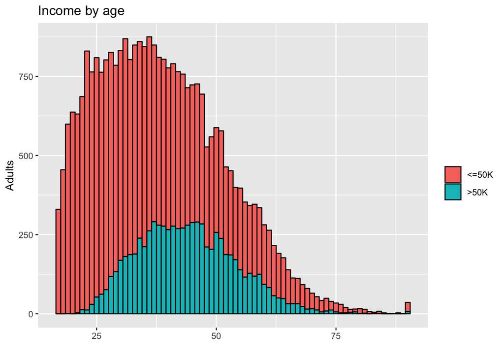

```r
# Relación con la variable age
ggplot(data,aes(age,fill=income))+geom_histogram(binwidth=1, color='black') +labs(x="",
y="Adults")+ guides(fill=guide_legend(title=""))+ggtitle("Income by age")
```

Se observa que para la mayoria de las observaciones ganan menos de 50K al año. Entre la población que superan los 50K al año se encuentran principalmente en la mitad de su carrera.

- Relación con la variable `workclass`

```r
summary(data$workclass)
```

```
##         Other       Private        Public Self-Employed
##            14         22696          4351          3657
```

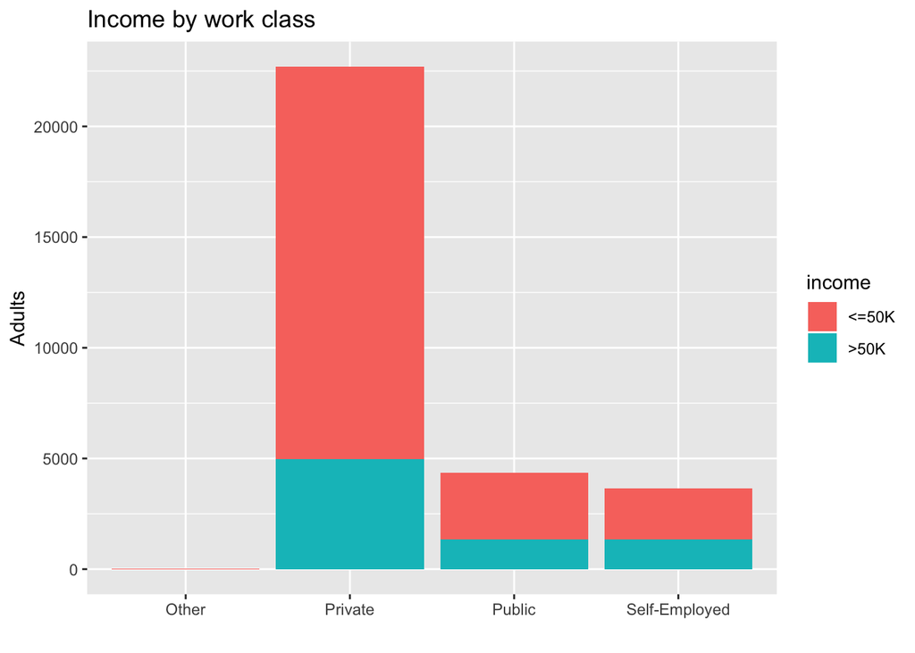

```r
ggplot(data,aes(workclass,fill=income))+geom_bar()+labs(x="",
y="Adults")+ggtitle("Income by work class")
```

```r
# Tabla de contingencia.
tabla_WCI <- table(data$workclass,data$income)
prop.table(tabla_WCI)
```

```
##
##                        <=50K         >50K
##   Other         0.0004557588 0.0000000000
##   Private       0.5772836773 0.1615665082
##   Public        0.0979881503 0.0436551859
##   Self-Employed 0.0752327625 0.0438179569
```

- Relación con la variable `education_num`

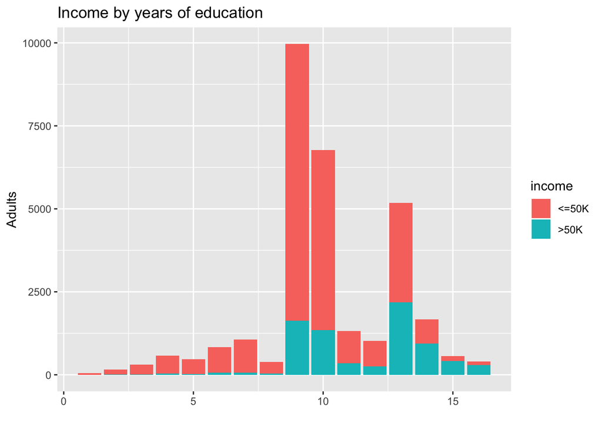

```r
ggplot(data,aes(education_num,fill=income))+geom_bar()+labs(x="",
y="Adults")+ggtitle("Income by years of education")
```

Vemos cómo la proporción en el grupo de ganar más de 50K al año aumenta a medida que aumentan los años de educación.

- Relación con la variable `marital_status`

```r
summary(data$maritalStatus)
```

```
## Married  Single
##   14749   15969
```

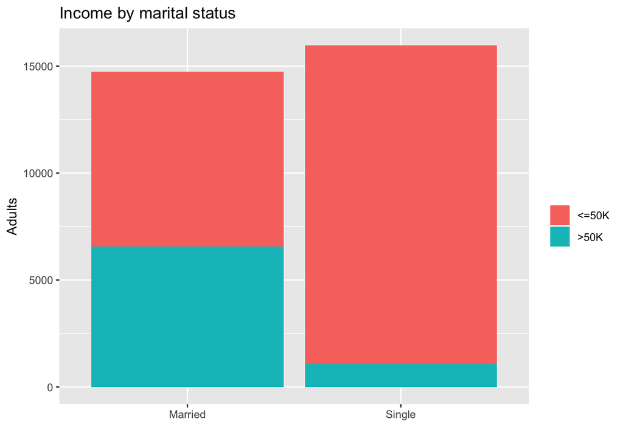

```r
ggplot(data,aes(maritalStatus,fill=income))+geom_bar() +labs(x="",
y ="Adults")+ guides(fill=guide_legend(title=""))+ggtitle("Income by marital status")
```

- Relación con la variable `cccupation`

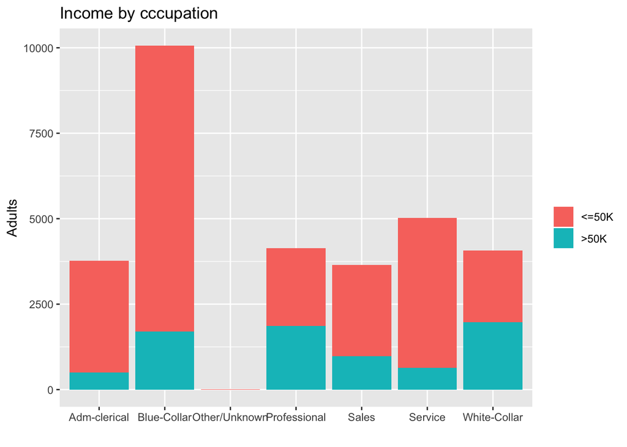

```r
ggplot(data,aes(occupation,fill=income))+geom_bar() +labs(x="",
y ="Adults")+ guides(fill=guide_legend(title=""))+ggtitle("Income by cccupation")
```

- Relación con la variable `sex`

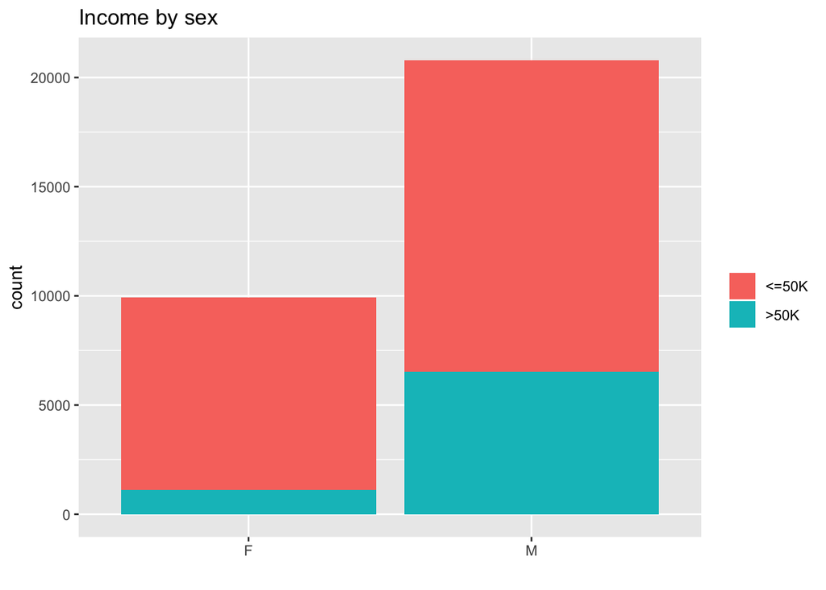

```r
ggplot(data,aes(sex,fill=income))+geom_bar() +labs(x="")+ guides(
  fill=guide_legend(title=""))+ggtitle("Income by sex")
```

```r
# Tabla de contingencia.
tabla_SI <- table(data$sex,data$income)
prop.table(tabla_SI)
```

```
##
##          <=50K       >50K
##   F 0.28657465 0.03668859
##   M 0.46438570 0.21235106
```

Visualización con respecto a todas la variables del estudio:

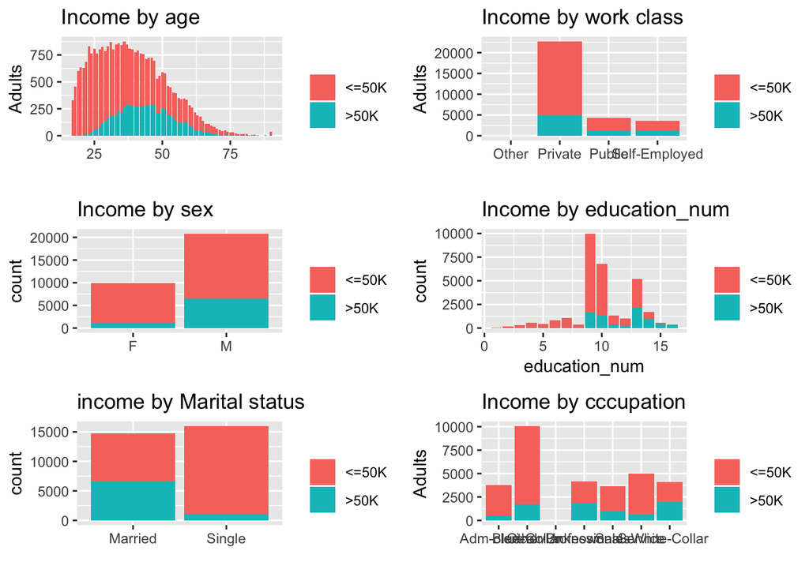

```r
grid.newpage()
# Relación con la variable age
plotbyAge <-ggplot(data,aes(age,fill=income))+geom_bar() +labs(x="",
y="Adults")+ guides(fill=guide_legend(title=""))+ggtitle("Income by age")
# Relación con la variable workclass
plotbyWorkclass <-ggplot(data,aes(workclass,fill=income))+geom_bar() +labs(
  x="",y="Adults")+ guides(fill=guide_legend(
  title=""))+ggtitle("Income by work class")
# Relación con la variable sex
plotbySex<-ggplot(data,aes(sex,fill=income))+geom_bar() +labs(
  x="")+ guides(fill=guide_legend(title=""))+ggtitle("Income by sex")
# Relación con la variable education_num
plotbyEducation_num<-ggplot(data,aes(education_num,fill=income))+geom_bar() +labs(
  x="education_num")+ guides(fill=guide_legend(title=""))+ggtitle(
    "Income by education_num")
# Relación con la variable marital_status
plotbyMarital_status <-ggplot(data,aes(maritalStatus,fill=income))+geom_bar() +labs(
x="")+ guides(fill=guide_legend(title=""))+ggtitle("income by Marital status")
# Relación con la variable occupation
plotbyOccupation<-ggplot(data,aes(occupation,fill=income))+geom_bar() +labs(x="",
y ="Adults")+ guides(fill=guide_legend(title=""))+ggtitle("Income by cccupation")

grid.arrange(plotbyAge,plotbyWorkclass,plotbySex,plotbyEducation_num,
plotbyMarital_status, plotbyOccupation, ncol=2)
```

### 5.3 Comprobación de la normalidad y homogeneidad de la varianza

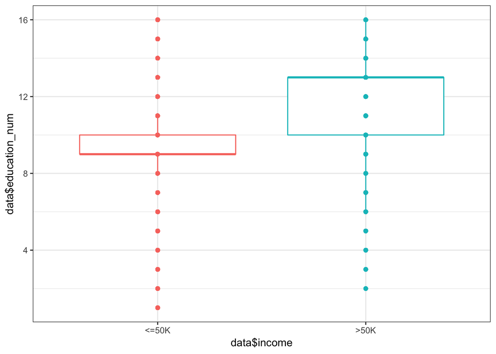

```r
# En primer lugar analizamos la varianza en funcion del gradio de estudios
ggplot(data = data, aes(x = data$income, y = data$education_num, colour = data$income)) +
  geom_boxplot() +
  geom_point() +
  theme_bw() +
  theme(legend.position = "none")
```

```r
var.test(x = data[data$income == ">50K", "education_num"],
         y = data[data$income == "<=50K", "education_num"] )
```

```
##
##  F test to compare two variances
##
## data:  data[data$income == ">50K", "education_num"] and data[data$income == "<=50K", "education_num"]
## F = 0.96148, num df = 7649, denom df = 23067, p-value = 0.03617
## alternative hypothesis: true ratio of variances is not equal to 1
## 95 percent confidence interval:
##  0.9271089 0.9974670
## sample estimates:
## ratio of variances
##          0.9614811
```

Vemos que el p-valor es inferior al 0.05 por tanto rechazamos la hipótesis nula aceptando la alternativa, lo que significa que ambas muestras presentan varianzas distintas.

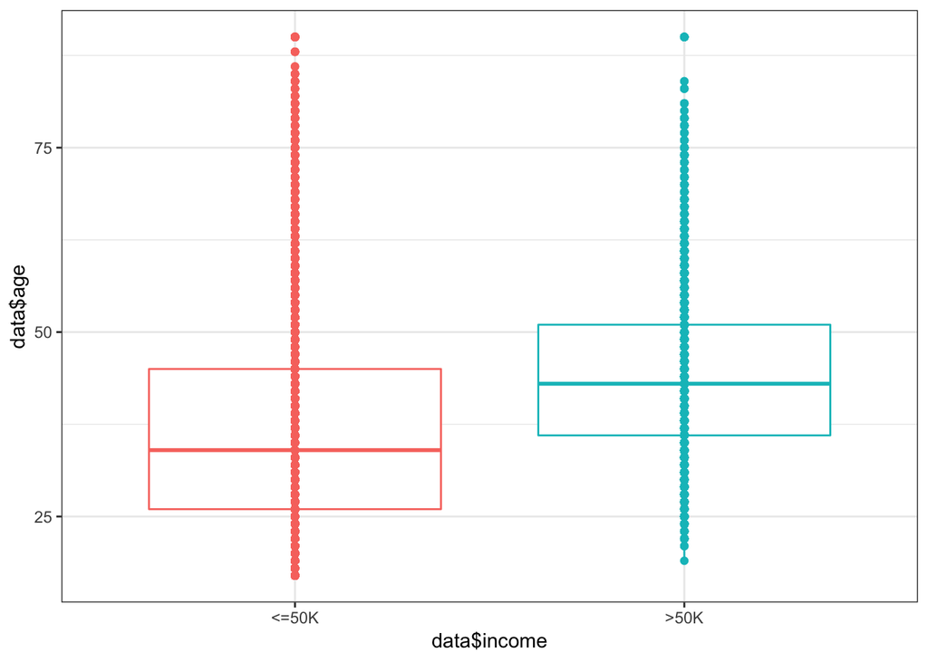

```r
# Ahora realizamos lo mismo en funcion de la edad
ggplot(data = data, aes(x = data$income, y = data$age, colour = data$income)) +
  geom_boxplot() +
  geom_point() +
  theme_bw() +
  theme(legend.position = "none")
```

```r
var.test(x = data[data$income == ">50K", "age"],
         y = data[data$income == "<=50K", "age"] )
```

```
##
##  F test to compare two variances
##
## data:  data[data$income == ">50K", "age"] and data[data$income == "<=50K", "age"]
## F = 0.58295, num df = 7649, denom df = 23067, p-value < 2.2e-16
## alternative hypothesis: true ratio of variances is not equal to 1
## 95 percent confidence interval:
##  0.5621143 0.6047730
## sample estimates:
## ratio of variances
##          0.5829544
```

En este caso, el p-valor es muy inferior al 0.05 por tanto no también tenemos que rechazar la hipótesis nula. Realizamos por último, el mismo análisis de la varianza en función de las horas de trabajo:

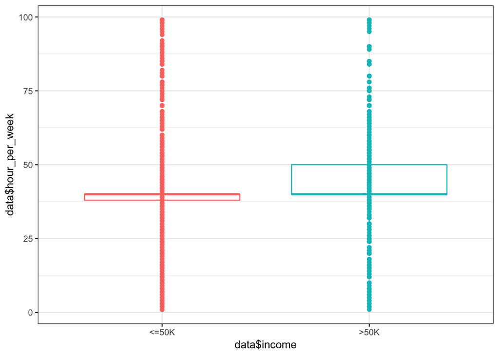

```r
# Ahora realizamos lo mismo en funcion de horas trabajadas a la semana
ggplot(data = data, aes(x = data$income, y = data$hour_per_week, colour = data$income)) +
  geom_boxplot() +
  geom_point() +
  theme_bw() +
  theme(legend.position = "none")
```

```r
var.test(x = data[data$income == ">50K", "hour_per_week"],
         y = data[data$income == "<=50K", "hour_per_week"] )
```

```
##
##  F test to compare two variances
##
## data:  data[data$income == ">50K", "hour_per_week"] and data[data$income == "<=50K", "hour_per_week"]
## F = 0.80408, num df = 7649, denom df = 23067, p-value < 2.2e-16
## alternative hypothesis: true ratio of variances is not equal to 1
## 95 percent confidence interval:
##  0.7753314 0.8341712
## sample estimates:
## ratio of variances
##          0.8040765
```

En el último caso vemos como también hemos de rechazar la hipótesis nula dado que el p-valor es muy inferior al 0.05, estamos por tanto ante dos poblaciones con varianzas distintas.

### 5.4 Aplicación de pruebas estadísticas para comparar los grupos de datos

Con el fin de conocer qué variables están directamente relacionadas unas con otras, vamos a calcular los coeficientes de correlación entre cada par de variables numéricas:

```r
varNumericas <- subset(data, select = c(1, 3, 7))
cor(varNumericas)
```

```
##                      age education_num hour_per_week
## age           1.00000000    0.04356708     0.1018794
## education_num 0.04356708    1.00000000     0.1512413
## hour_per_week 0.10187939    0.15124134     1.0000000
```

Vemos que existe entre ellas una correlacion positiva aunque muy cercana a 0, lo que nos da a entender pueden llegar a ser bastante independientes.

Vamos a mirar ahora si existe relacion entre el nivel de ingresos y el sector laboral o el sexo. Para el estudio de dependencia entre estas variables, vamos a realizar el Test de Chi-Cuadrado:

```r
t1 <- table(data$income, data$workclass)
chisq.test(t1)
```

```
##
##  Pearson's Chi-squared test
##
## data:  t1
## X-squared = 475, df = 3, p-value < 2.2e-16
```

```r
t2 <- table(data$income, data$sex)
chisq.test(t2)
```

```
##
##  Pearson's Chi-squared test with Yates' continuity correction
##
## data:  t2
## X-squared = 1440.4, df = 1, p-value < 2.2e-16
```

Vemos que para ambas el valor es significativamente menor del 0.05 por tanto, podemos decir que están relacionadas.

Vamos a ver por último, si existe relación entre las horas de trabajo y el nivel de ingresos y entre las horas de trabajo y el tipo de trabajo (workclass) mediante modelos de regresión lineal simple:

```r
regresionSimpleIngresosVShorasTrabajo <- lm(hour_per_week ~ income, data = data)
summary(regresionSimpleIngresosVShorasTrabajo)
```

```
##
## Call:
## lm(formula = hour_per_week ~ income, data = data)
##
## Residuals:
##     Min      1Q  Median      3Q     Max
## -44.706  -5.706   0.628   4.294  59.628
##
## Coefficients:
##             Estimate Std. Error t value Pr(>|t|)
## (Intercept) 39.37190    0.07683  512.49   <2e-16 ***
## income>50K   6.33398    0.15395   41.14   <2e-16 ***
## ---
## Signif. codes:  0 '***' 0.001 '**' 0.01 '*' 0.05 '.' 0.1 ' ' 1
##
## Residual standard error: 11.67 on 30716 degrees of freedom
## Multiple R-squared:  0.05223,    Adjusted R-squared:  0.0522
## F-statistic:  1693 on 1 and 30716 DF,  p-value: < 2.2e-16
```

```r
regresionSimpleTipoTrabajoVShorasTrabajo <- lm(hour_per_week ~ workclass, data = data)
summary(regresionSimpleTipoTrabajoVShorasTrabajo)
```

```
##
## Call:
## lm(formula = hour_per_week ~ workclass, data = data)
##
## Residuals:
##     Min      1Q  Median      3Q     Max
## -44.763  -2.267  -0.267   4.733  58.733
##
## Coefficients:
##                        Estimate Std. Error t value Pr(>|t|)
## (Intercept)              32.714      3.168  10.327  < 2e-16 ***
## workclassPrivate          7.553      3.169   2.383   0.0172 *
## workclassPublic           7.774      3.173   2.450   0.0143 *
## workclassSelf-Employed   13.049      3.174   4.111 3.94e-05 ***
## ---
## Signif. codes:  0 '***' 0.001 '**' 0.01 '*' 0.05 '.' 0.1 ' ' 1
##
## Residual standard error: 11.85 on 30714 degrees of freedom
## Multiple R-squared:  0.02203,    Adjusted R-squared:  0.02193
## F-statistic: 230.6 on 3 and 30714 DF,  p-value: < 2.2e-16
```

Vemos que tanto el nivel de ingresos >50K como la clase de trabajo “workclassSelf-Employed” influyen en el número de horas de trabajo.

## 6. Representación de los resultados a partir de tablas y gráficas

En primer lugar, mostramos un gráfico que muestra la influencia que tiene el sexo y el sector laboral en el nivel de ingresos, algo que sospechábamos previamente pero que el estudio nos ha revelado (sobretodo con el sexo de la persona);

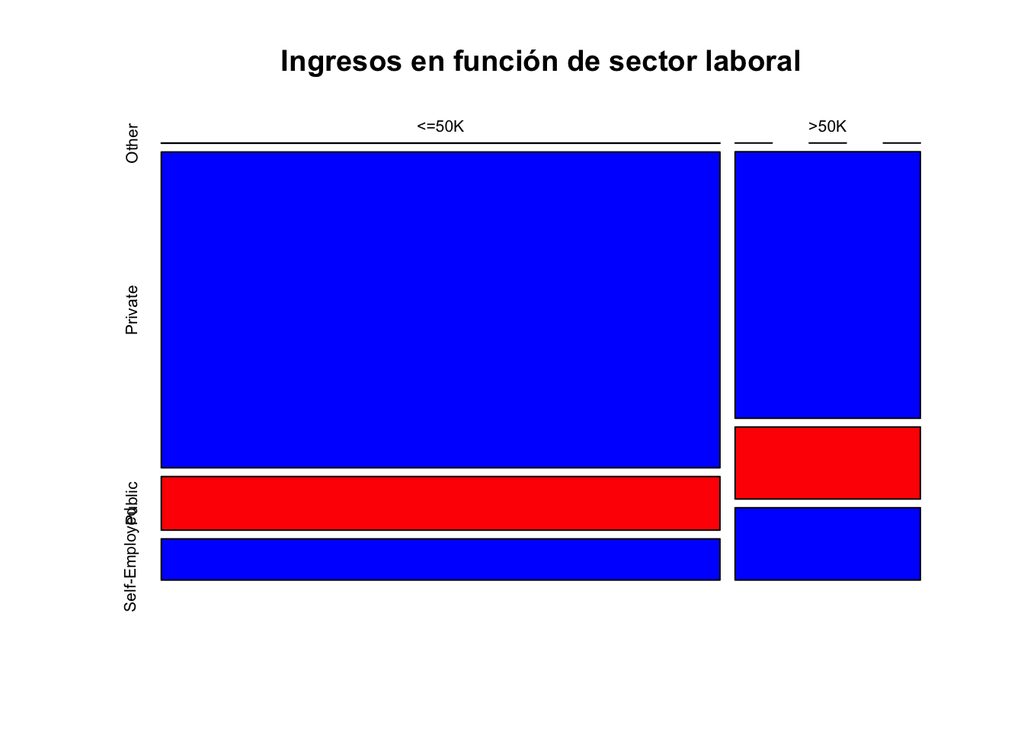

```r
plot(t1, col = c("red", "blue"), main = "Ingresos en función de sector laboral")
```

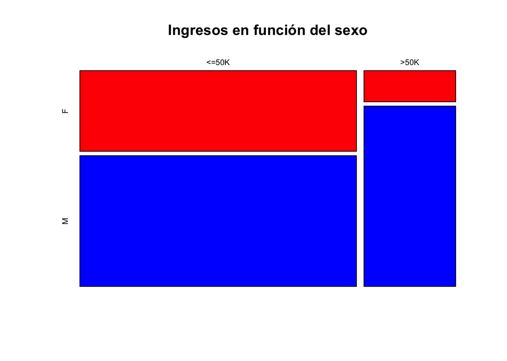

```r
plot(t2, col = c("red", "blue"), main = "Ingresos en función del sexo")
```

También nos ha arrojado otra conclusión y es que la gran mayoría de la población tiene un nivel de ingresos inferior a los 50K y que aquellas personas con un nivel de ingresos superior, ganan cantidades altas durante más años en comparación y empiezan a dejar de ganar dinero más lentamente y de una manera menos pronunciada.

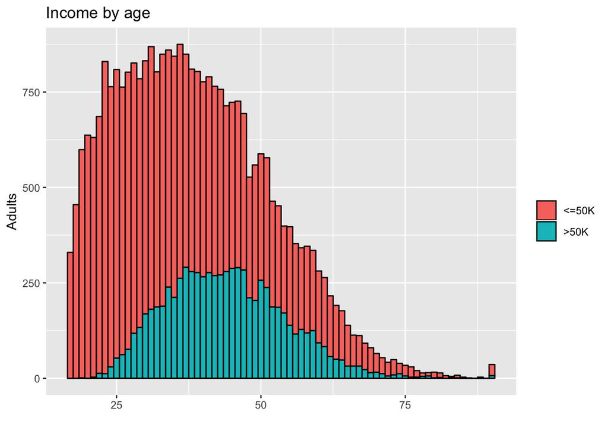

```r
ggplot(data,aes(age,fill=income))+geom_histogram(binwidth=1, color='black') +labs(x="",
y="Adults")+ guides(fill=guide_legend(title=""))+ggtitle("Income by age")
```

## 7. Resolución del problema.

Creemos que, existen diversos factores en este Dataset bastante significativos que nos pueden ayudar a determinar si una persona tiene un nivel de ingresos u otro, que era lo que nos planteábamos desde un inicio. Obviamente, se trata de únicamente la fase de preparación validación y análisis básico, pero es un Dataset válido para llevar a cabo un proyecto de minería de datos que sirva para predecir el nivel de ingresos en función de un conjunto de atributos, permitiendonos así por ejemplo realizar clasificaciones o agrupaciones por niveles de ingresos de personas a partir de unos determinados datos e entrada.

## 8. Contribuciones

| Contribuciones | Firma |
| --- | --- |
| Investigación previa | AL, CV |
| Introducción | AL, CV |
| Descripción | AL, CV |
| Integración | AL, CV |
| Limpieza de datos | AL, CV |
| Análisis de datos | AL, CV |
| Representación de los res. | AL, CV |
| Resolución problema | AL, CV |